# Supplementary Materials: Pilot Analysis

ADF Clarke and AE Hughes

# 1 Intro

## 1.1 Setup and Data Import

```r
# set ggplot2 theme
theme_set(ggthemes::theme_tufte())

# use parallel cores for mcmc chains!
options(mc.cores = parallel::detectCores())

# reduce the number of decimal places
options(digits = 3)

# functions used for our Bayesian re-analysis
source("../scripts/our_functions.R")

# set seed to make sure everything is reproducible
set.seed(100320021)
```

## 1.2 Import and Remove Outliers

We will import data from the pilot experiment (with pre-processing already in place, e.g. incorrect trials removed, 1st and 100th percentile reaction times removed). $d1$ is the training data set (Experiment 1) and $d2$ is the test data set.

```r
source("1_pre_process_pilot.R")

summary(d1)
```

```
##  observer     feature          nd          accuracy       rt
##  1:414    purple  :406   Min.   : 0.0   Min.   :1   Min.   :0.434
##  2:390    diamond :412   1st Qu.: 1.0   1st Qu.:1   1st Qu.:0.574
##  3:408    circle  :418   Median : 4.0   Median :1   Median :0.658
##  5:414    triangle:373   Mean   :10.4   Mean   :1   Mean   :0.706
##  6:407    orange  :398   3rd Qu.:19.0   3rd Qu.:1   3rd Qu.:0.794
##  7:380    pink    :406   Max.   :31.0   Max.   :1   Max.   :1.453
##       lnd
##  Min.   :0.00
##  1st Qu.:0.69
##  Median :1.61
##  Mean   :1.82
##  3rd Qu.:3.00
##  Max.   :3.47
```

```r
summary(d2)
```

```
##  observer   feature1           feature2               nd          accuracy
##  1:637    Length:3720        Length:3720        Min.   : 0.0   Min.   :1
##  2:612    Class :character   Class :character   1st Qu.: 1.0   1st Qu.:1
##  3:628    Mode  :character   Mode  :character   Median : 4.0   Median :1
##  5:641                                          Mean   :10.7   Mean   :1
##  6:635                                          3rd Qu.:19.0   3rd Qu.:1
##  7:567                                          Max.   :31.0   Max.   :1
##        rt             lnd
##  Min.   :0.434   Min.   :0.00
##  1st Qu.:0.547   1st Qu.:0.69
##  Median :0.615   Median :1.61
##  Mean   :0.648   Mean   :1.84
##  3rd Qu.:0.716   3rd Qu.:3.00
##  Max.   :1.454   Max.   :3.47
```

# 2 Fit Models to Data

For hypothesis 1, we fit the following models:

- A shifted lognormal model to the training data
- A lognormal model to the training data
- A normal model to the training data

For hypothesis 2, we fit the following models:

- A shifted lognormal model to the training data, with a linear number of distractors

The models take a little while to run, so do not run by default in this document. Set $eval=TRUE$ to run them.

Note that our approach differs slightly from the original methods proposed by Buetti et al (2019). In their manuscript, due to the between-subjects nature of the design, $a$ was calculated at the level of each sub-experiment. However, in our within-subjects version, we will use $a$ from the single feature experiments (i.e. Experiment 1) to predict $a$ in the compound feature experiments (i.e. Experiment 2).

```r
source("2_fit_pilot_models.R")
```

## 2.1 Plotting prior predictions

We can see that the priors chosen for our models centre the estimates of $D$ around 0 (i.e. we are not making any assumptions about what we expect the slopes to be).

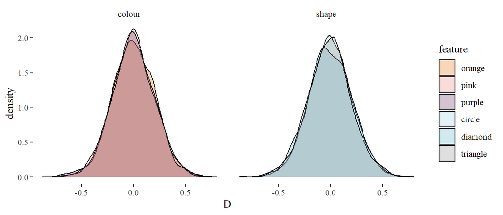

Figure 2.1: Prior predictions for our models.

```r
m1b <- readRDS("pilot1_prior.model")

source("../scripts/our_functions.R")


samples1b <- get_slopes_pilot(m1b, 1) %>% select(-observer, -rD) %>% distinct()


colourPalette <- c("#e78429", "#ed968c", "#7c4b73","#aadce0", "#72bcd5", "528fad")

samples1b %>% mutate(feature_type = if_else(
  feature %in% c("purple", "orange", "pink"), "colour", "shape")) %>%
  ggplot(aes(D, fill = feature)) +
  geom_density(alpha = 0.33) +
  facet_wrap(~feature_type) +
  scale_fill_manual(values=colourPalette, limits = c("orange", "pink","purple", "circle", "diamond", "triangle"))
```

## 2.2 Hypothesis 1

Test whether using a shifted-lognormal distribution gives a better model than a lognormal or normal.

```r
m_sft <- readRDS("pilot1.model")
m_nrl <- readRDS("pilot1_normal.model")
m_log <- readRDS("pilot1_lognormal.model")

tibble(model = c("shifted lognormal", "normal", "lognormal"),
  LOO = model_weights(m_sft, m_nrl, m_log, weights = "loo"),
             WAIC = model_weights(m_sft, m_nrl, m_log, weights = "waic")) %>%
  knitr::kable()
```

| model | LOO | WAIC |
| --- | --- | --- |
| shifted lognormal | 1 | 1 |
| normal | 0 | 0 |
| lognormal | 0 | 0 |

The shifted lognormal model gives the best prediction 100% of the time, meaning that we have strong evidence that we should prefer this model over the others.

Some plots to illustrate our models:

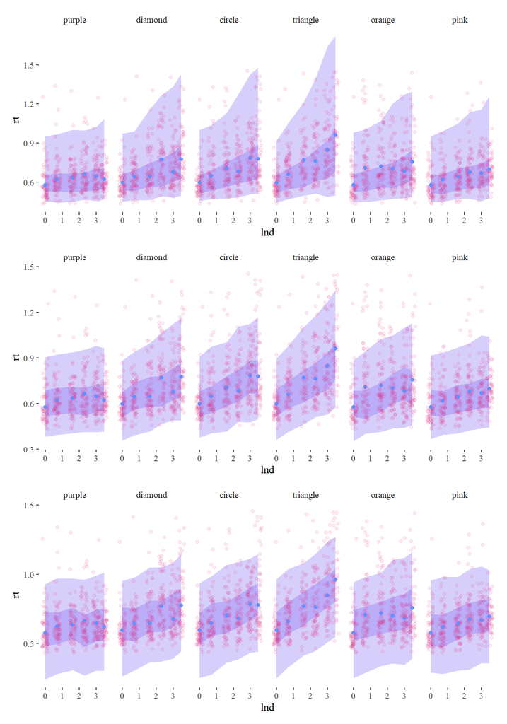

Figure 2.2: Model predictions for (top) shifted log normal model, (middle) log normal model and (bottom) normal model.

## 2.3 Hypothesis 2

Here, we want to verify that using log(number of distractors) in our model is superior to n(distractors).

| model | LOO | WAIC |
| --- | --- | --- |
| loglinear in n | 1 | 1 |
| linear in n | 0 | 0 |

Our loglinear model is preferred 100% of the time, supporting the hypothesis that this is the best model structure for the data.

# 3 Hypothesis 3

## 3.1 Fixed effect of D (group average)

Can we predict $D$ in the double-feature case from data in the single-feature case? Which method has the lowest mean absolute prediction error?

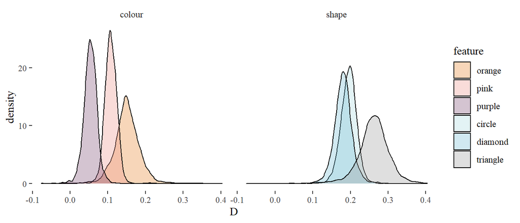

Figure 3.1: Predicting the group average D.

```r
m1 <- readRDS("pilot1.model")
samples1 <- get_slopes_pilot(m1, 1) %>% select(-observer, -rD) %>% distinct()


# circle, diamond, orange, pink, purple, triangle
colourPalette <- c("#e78429", "#ed968c", "#7c4b73","#aadce0", "#72bcd5", "528fad")

samples1 %>% mutate(feature_type = if_else(
  feature %in% c("purple", "orange", "pink"), "colour", "shape")) %>%
  ggplot(aes(D, fill = feature)) +
  geom_density(alpha = 0.33) +
  facet_wrap(~feature_type) +
  scale_fill_manual(values=colourPalette,  limits = c("orange", "pink","purple", "circle", "diamond", "triangle"))
```

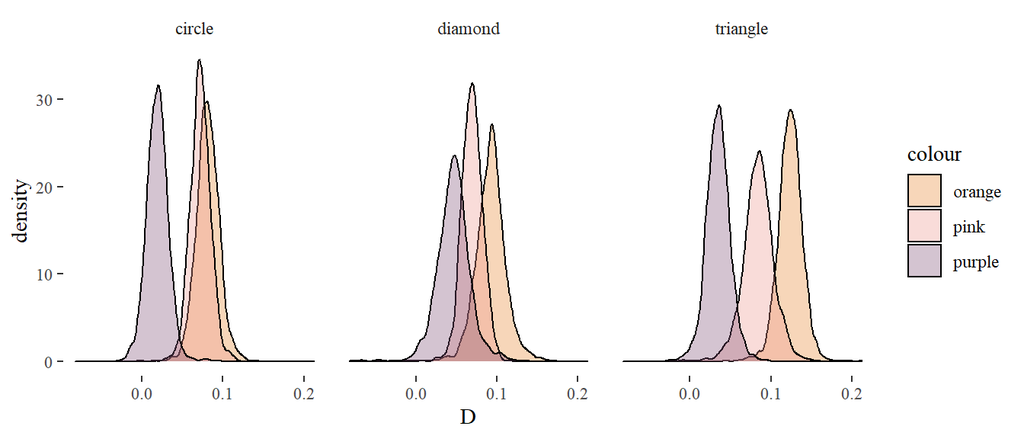

Figure 3.2: Predicting person-level effects.

```r
m2 <- readRDS("pilot2_random.model")
samples2 <- get_slopes_pilot(m2, 1) %>% select(-observer, -rD) %>% distinct()

colourPalette2 <- c("#e78429", "#ed968c", "#7c4b73")


samples2 %>% separate(feature, into = c("colour", "shape")) %>%
  ggplot(aes(D, fill = colour)) +
  geom_density(alpha = 0.33) +
  facet_grid(.~shape) +
  scale_fill_manual(values=colourPalette2)
```

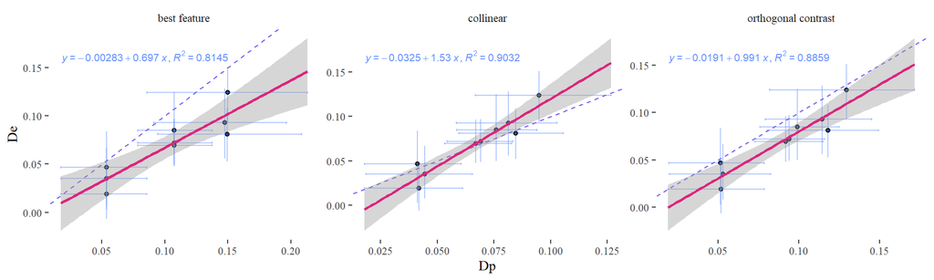

Figure 3.3: Predicted D plotted against empirical D for our pilot data.

```r
calc_D <- function(feature1, feature2) {

  D1 <- filter(samples1, feature == feature1)$D
  D2 <- filter(samples1, feature == feature2)$D

  # now calculate D_overall using the three proposed methods
  D_collinear = 1/((1/D1) + (1/D2))
  D_best_feature = pmin(D1, D2)
  D_orth_contrast =  1/sqrt(1/(D1^2) + (1/D2^2))

 return(tibble(.draw = 1:2000,
               feature = paste(feature1, feature2, sep = "_"),
                feature1 = feature1, feature2 = feature2,
                collinear = D_collinear,
                `best feature` = D_best_feature,
                `orthogonal contrast` = D_orth_contrast))

}


things_to_calc <- samples2 %>% select( -D, -.draw) %>%
  distinct() %>%
  separate(feature, c("feature1", "feature2"))


slopes <- pmap_df(things_to_calc, calc_D) %>% full_join(samples2, by = c(".draw", "feature")) %>%
  pivot_longer(c(collinear, `best feature`, `orthogonal contrast`), names_to = "method", values_to = "Dp") %>%
  select(-feature) %>%
  pivot_longer(c(D, Dp), names_to = "type", values_to = "D") %>%
  group_by(feature1, feature2, method, type)

slopes %>%
  median_hdci(D) %>%
  unite(D, D, .lower, .upper) %>%
  select(-.width, -.point, -.interval) %>%
  pivot_wider(names_from = "type", values_from = "D") %>%
  separate(D, into = c("De", "De_min", "De_max"), sep = "_", convert = TRUE) %>%
  separate(Dp, into = c("Dp", "Dp_min", "Dp_max"), sep = "_", convert=  TRUE) %>%
  ggplot(aes(x = Dp, xmin = Dp_min, xmax = Dp_max, y = De, ymin = De_min, ymax = De_max)) +
  geom_point() +
  geom_errorbar(alpha = 0.5, colour = "#648FFF") +
  geom_errorbarh(alpha = 0.5, colour = "#648FFF") +
  geom_abline(linetype = 2, colour = "#785EF0") +
  geom_smooth(method = "lm", fullrange  = T, colour = "#DC267F") +
      stat_poly_eq(formula = y ~ x,
               aes(label = paste(..eq.label.., ..rr.label.., sep = "*plain(\",\")~")),
               parse = TRUE, size = 2.8, label.y = 0.9, coef.digits = 3, rr.digits = 4, colour="#648FFF") +
  facet_wrap(~method, scales = "free") +
  scale_colour_manual(values = c("#648FFF", "#648FFF", "#648FFF"))
```

Calculate mean absolute prediction error:

```r
slopes  %>%
  ungroup() %>%
 pivot_wider(names_from = "type", values_from = "D") %>%
  mutate(abs_err = abs(D-Dp)) %>%
  group_by(feature1, feature2, method) %>%
  summarise(mean_abs_err = mean(abs_err)) %>%
  pivot_wider(names_from = "method", values_from = "mean_abs_err") %>%
  ungroup() -> slopes_err


  add_row(slopes_err, feature1 = "sum", feature2 = "over all",
          `best feature` = sum(slopes_err[3]),
          collinear = sum(slopes_err[4]),
          `orthogonal contrast` = sum(slopes_err[5])) %>%
    knitr::kable()
```

| feature1 | feature2 | best feature | collinear | orthogonal contrast |
| --- | --- | --- | --- | --- |
| orange | circle | 0.069 | 0.015 | 0.038 |
| orange | diamond | 0.056 | 0.019 | 0.027 |
| orange | triangle | 0.036 | 0.031 | 0.021 |
| pink | circle | 0.037 | 0.012 | 0.023 |
| pink | diamond | 0.039 | 0.012 | 0.024 |
| pink | triangle | 0.028 | 0.018 | 0.022 |
| purple | circle | 0.036 | 0.025 | 0.034 |
| purple | diamond | 0.022 | 0.018 | 0.020 |
| purple | triangle | 0.024 | 0.017 | 0.023 |
| sum | over all | 0.346 | 0.166 | 0.231 |

Overall, the collinear model has the lowest mean absolute error, in line with the findings from the original manuscript.

# 4 Hypothesis 4: Predicting Reaction Times

Finally, we check which model offers the best prediction of reaction times.

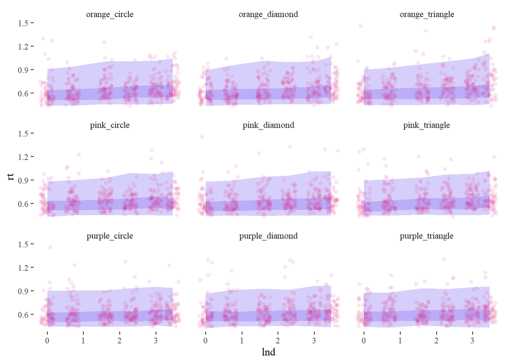

Figure 4.1: Predicted RTs for our pilot data, using collinear contrast combination.

| model | posterior probability |
| --- | --- |
| collinear | 0.280 |
| best feature | 0.396 |
| orthogonal contrast | 0.324 |

With the pilot data, all three models receive approximately the same predictive weight, meaning that we are not able to distinguish between them: we do not have evidence for one model over the others.